# Taller Enfoque Simulacion Basado en Eventos Discretos

##Integrantes ##Deimer Castillo ##Rances Rodriguez ##Iveth Medina

##Punto 1

En un modelo de cola con un solo servidor, la llegada de unos clientes sigue un proceso no homogéneo de Poisson, cuya tasa inicial es 3 por hora. La tasa se incrementa de forma lineal hasta que alcanza las 12 llegadas por hora a las 5 horas. Finalmente, la tasa de llegada de clientes decrece linealmente hasta que llega a 5 llegadas por hora después de 5 horas más. Realice la simulación durante las 10 horas si el tiempo de servicio sigue una distribución exponencial con tasa de 9 por hora. Use la simulación para estimar el valor esperado de clientes atendidos durante las 10 horas de simulación. Verifique que la distribución de llegada de los clientes sigue el proceso de Poisson descrito anteriormente. Ejecute 1000 veces la simulación para obtener el promedio del estimado.

-Variable tiempo t -Variables contadoras: número de llegadas y numero de salidas -Estado del Sistema: número de clientes en el sistema -Lista de eventos: {tLL, tS, T}

Función proceso no homogéneo

```r
lambdat<-function(x) ((1.8*x)+3)*I(x<=5)+((-1.4*x)+19)*I(x>5&x<=10)
curve(lambdat(x),xlim=c(0,10),ylab="lambda(x)",col="red")
```

Máximo de la función anterior

```r
opt <- optimize(lambdat, c(0, 10), maximum=TRUE)
m <- opt$objective
cat("maximo =",m)
```

Simulación de las llegadas de clientes en 10 horas

```r
S<-vector()
u1<-vector()
u2<-vector()
procpois<-function(Tmax,lambda) {
  t<-0;I<-0;i<-1
  repeat {
    u1[i]<-runif(1)
    t<-t-((1/lambda)*log(u1[i]))
    if (t>Tmax) {
      break
    }
    if (t<=Tmax) {
      u2[i]<-runif(1)
    }
    if(u2[i]<=(lambdat(t)/lambda)) {
      I<-I+1;S[I]<-t
    }
    i<-i+1
  }
return(S)
}

LL<-procpois(10,m)
hist(LL,main = "Poisson no homogéneo",breaks = 12,xlab = "t (horas)")
curve(lambdat(x),xlim=c(0,10),ylab="lambda(t)",col="red",add=TRUE)
LL[length(LL)+1]<-Inf
```

[output not shown]

Tiempo de servicio con distribución exponencial con tasa de 9 por hora

```r
# Generación de tiempo de servicio
tserv<-function() {
  t<- (-1/9)*log(1-runif(1))
  return(t)
}
tserv()
```

Simulación del sistema

```r
# Evolución del sistema
unserv<-function(){
  LL<-procpois(10,m)
  LL[length(LL)+1]<-Inf
  t<-0
  NLL<-0  #número de llegadas hasta t
  NS<-0   # contador de salidas
  n<-0  #numero de clientes en el sistema en t
  Y<-vector() #tiempos de servicio
  Sal<-vector()       # output instantes de salida
  c<-vector()     # clientes en el sistema en cualquier t
  tLL <- LL[1]  #instante de llegada del cliente 1
  tS<-Inf   #instante de salida del sistema para el cliente i
  tm<-vector() #tiempo cliente en el sistema
  i<-1
  j<-1
  repeat
  {
    #Caso 1
    if(tLL <= tS)#llega un cliente
    {
      t <- tLL
      NLL <- NLL+1
      i<-i+1
      tLL <- LL[i]
      n<-n+1
      c[length(c)+1]<-n  # recogemos el número de clientes en el sistema
      if(n==1){
        Y[j] <- tserv()
        tS <- t+Y[j]
        j <- j+1
      }

    }

    #caso2
    if(tS <= tLL)#un cliente sale del servidor 1
    {
      t<-tS
      NS<-NS + 1
      n<-n-1
      c[length(c)+1]<-n
      Sal[NS]<-t
      tm[NS]<-Sal[NS]-LL[NS]  # tiempo en el sistema
      if(n==0)
      {
        tS<-Inf
      }
      if(n>0)
      {
        Y[j]<-tserv()
        tS<-t+Y[j]
        j<-j+1
      }

    }
    #caso 3
    if (n == 0 & tLL == Inf) # si no quedan clientes
    {
      break
    }
  }

  if(tS==Inf)tS<-t
  resultados<-list("tiempos en el sistema",tm,"clientes en el sistema",c,
                "tiempo medio cliente en el sistema",
                mean(tm,na.rm=TRUE),
                "número medio clientes en el sistema",mean(c),
                "tiempos atención",Y,
                "última salida",tS,
                "clientes atendidos",NLL)

    return(resultados)
}
```

Ejecución de la simulación 1000 veces

```r
clientes_atendidos <- vector()
for (i in 1:1000) {
  out <- unserv()
  clientes_atendidos[i] <- out[[14]]
}

mean(clientes_atendidos)
hist(clientes_atendidos,main = "Frecuencia de clientes atendidos",xlab = "clientes atendidos en 10 horas" )
```

[output not shown]

##Punto 2

Un sistema necesita $n$ máquinas funcionando. Para asegurarse en caso de fallas mecánicas se dispone de algunas máquinas adicionales. Si una máquina falla es inmediatamente reemplazada por una de las máquinas disponibles. La máquina con fallos es enviada a la sección de reparación. La sección de reparación consiste en una sola persona que repara las máquinas de una en una. Una vez la máquina es reparada se reincorpora al conjunto de máquinas disponibles como reemplazo. Todos los tiempos de reparación son variables aleatorias independientes con distribución de probabilidad $G$. Cada vez que una maquina es puesta en uso, el tiempo que funciona antes de sufrir una falla mecánica es una variable aleatoria con función de probabilidad $F$. Se dice que el sistema colapsa cuando una máquina falla y no hay máquinas extra disponibles para reemplazo. Asumiendo que inicialmente existen $n + s$ máquinas funcionales de las cuales $n$ están en uso, y $s$ pueden ser utilizadas para reemplazar las máquinas que fallen, encuentre el tiempo esperado $T$, en el cual el sistema colapsa después de ejecutar la simulación 100 veces, si $n = 4$, $s = 3$, $F(x) = 1 - e^{-x}$, y $G(x) = 1 − e^{-2x}$. Realice el análisis del sistema y utilizando la estrategia de simulación basada en eventos discretos implemente la simulación en R.

- Variable de tiempo t
- Variables de estado del sistema: número de máquinas descompuestas
- Eventos: una máquina se descompone, una máquina termina de ser reparada
- Lista de sucesos: {t1…tn, tf}, tf (tiempo en que una máquina en reparación vuelve a funciona). t1..tn (tiempos en orden de las fallas de n máquinas)

Función de servicio

```r
#Se crea la función del tiempo de servicio
Ts <- function(n, lambda) {
  u <- runif(n)
  x <- -(1/lambda) * log(u)
  return(x)
}
```

Simulación del sistema

```r
#Se desarrolla el sistema
Tv = c(0)
for (i in 1:100){
  TT = 0
  N = 4
  S = 3
  R = 0

  Tf = Ts(1000,1)
  Tr = Ts(1000,2)
  i = 1
  j = 1

  # Primer fallo
  TT = TT + Tf[i]
  S = S - 1
  R = R + 1
  i = i + 1

  while(TRUE){
    #
    if(R>0){
      if(Tf[i]>Tr[j]){
        TT = TT + Tr[j]
        S = S + 1
        R = R - 1
        Tf[i] = Tf[i] - Tr[j]
        j = j + 1
      }

      if(Tf[i]<Tr[j]){
        TT = TT + Tf[i]
        if(S==0){
          break
        }else{
          S = S - 1
          R = R + 1
          Tr[j]= Tr[j] - Tf[i]
          i = i + 1
        }
      }

    }else{
      TT = TT + Tf[i]
      S = S - 1
      R = R + 1
      i = i + 1
    }

  }
  Tv = c(Tv,TT)


}
meanT = mean(Tv)
meanT
```

```
[1] 36.13902
```

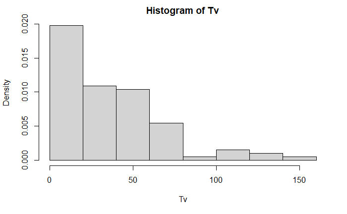

```r
hist(Tv,freq=FALSE)
```

El tiempo esperado es de 36.13 para que el sistema colapse después de ejecutar la simulación 100 veces.

##Punto 3 Un sistema experimenta choques que ocurren de acuerdo con un proceso de Poisson que tiene una tasa de 1 por hora. Cada choque tiene una cierta cantidad de daños asociados. Estos daños son asumidos como variables aleatorias independientes (que también son independientes del tiempo en el cual ocurre el choque), y que tiene la siguiente función de densidad de probabilidad:

$f(x) = xe^{-x}, x > 0$

Los daños se disipan en el tiempo con una tasa exponencial $\alpha$ – Esto es, un choque cuyo daño inicial es $y$ tendrá un valor de daño igual a $ye^{-\alpha s}$ en el tiempo $s$ después de que el choque ocurra. Adicionalmente, los valores de daño son acumulativos. Así, por ejemplo, si en el instante $t$ ha habido un total de 2 choques, originados en los tiempos $t_{1}$ y $t_{2}$, y que tuvieron daños iniciales $y_{1}$ y $y_{2}$, entonces el daño total en el instante $t$ es $\sum_{i=1}^{2} y_{i}e^{-\alpha (t-t_{i})}$. El sistema falla cuando el daño total excede una constante fija $C$.

Suponga que estamos interesados en usar un estudio de simulación para estimar el valor del tiempo promedio en el cual el sistema falla. Defina los eventos, variables de estado del sistema, variables contadoras y variables de salida de este modelo. Realice una implementación de este modelo en lenguaje de programación R. Extienda el programa para realizar $k$ réplicas que permita estimar el valor del tiempo promedio en el cual el sistema falla, si tenemos los valores de $\alpha = 0.5$, $C = 5$, y $k = 1000$. ¿Cuál es ese tiempo promedio de falla?

Simulacion sigue una distribución de Poisson

```r
# Se genera una lista de tiempos en los que ocurre un choque, sigue una distribucion de Poisson


choque.t <- function(T, lambda) {
    S <- vector()
    t <- 0
    I <- 0
    repeat {
        u1 <- runif(1)
        t <- t-(1/lambda)*log(u1)
        if (t > T) {
            break
        }
        I <- I+1
        S[I] <- t
    }
    return(S)
}

# Los danios causados por el choque -> PDF
valor_choque.pdf <- function(x){
    x * exp(-x)
}
```

```r
valor_choque.r <- function(){

    # Constante que garantiza f(y) < cg(y) al graficar las distribuciones
    c <- 5

    repeat {

        # Distribucion exponencial
        y <- rexp(1)

        # Uniforme
        u <- runif(1)

        if (u <= (valor_choque.pdf(y) / (dexp(y) * c))) {
            x <- y
            break
        }
    }
    x
}
```

Simulación del modelo

```r
modelo <- function(k, a, C) {

    tiempos <- vector()
    for (n in 1:k){
        # Se genera una lista de tiempos de choque
        # Los tiempos son independientes entre sí,Tmax = 100
        t_golpe <- choque.t(100, 1)

        # Vector de danios
        d_total <- 0
        d <- vector()

        # Dos eventos (los golpes y la parada) asi que se itera sobre la lista de eventos hasta llegar al
        # evento de parada

        # Contador de iteraciones
        i <- 1
        for (t in t_golpe) {

            d[i] <- valor_choque.r()

            # Calculo el danio actual luego del golpe
            d_total <- 0
            j <- 1
            for (d_actual in d) {
                # se itera sobre un vector de golpes y calculo su danio para el tiempo t considerando que este decrece con el tiempo
                d_total <- d_total + d_actual * exp(-a * (t - t_golpe[j]))
                j <- j + 1
            }

            # Si el danio supera el maximo, se llega al evento de parada
            if (d_total > C) {
                break
            }

            i <- i + 1
        }

        tiempos[n] <- t
    }

    tiempos
}

# Corro el modelo con 1000 iteraciones
k <- 1000

# Razon de decrecimiento de daÃ±o de choque con respecto al tiempo
a <- 0.5

# Danio maximo antes de que la maquina falle
C <- 5

tiempos <- modelo(k, a, C)

cat("Luego de", k, "iteraciones.\n")
```

```
Luego de 1000 iteraciones.
```

```r
cat("Tiempo promedio de parada:", mean(tiempos), "horas\n")
```

```
Tiempo promedio de parada: 5.221597 horas
```

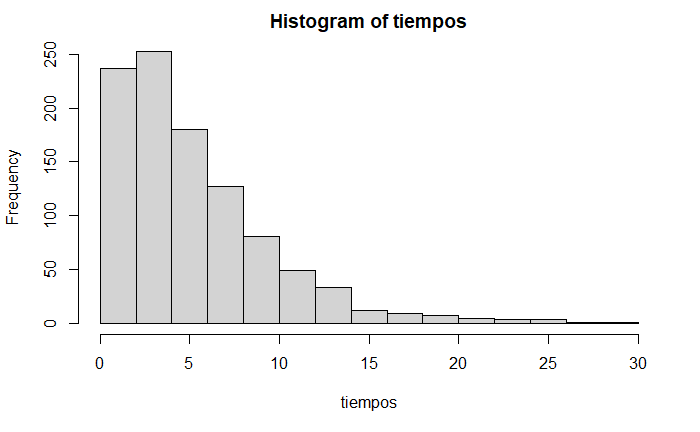

```r
hist(tiempos)
```

El tiempo promedio para que se detenga, es decir que el sistema falle es de aproximadamente 5.22 horas